# Лабораторная работа 1: «Метод обратного распространения ошибки»

## Цели работы

**Цель** — изучить метод обратного распространения ошибки для обучения глубоких нейронных сетей на примере двухслойной полносвязной нейронной сети (один скрытый слой).

## Задачи работы

Выполнение лабораторной работы предполагает решение следующих задач:

1. Изучить общую схему работы метода обратного распространения ошибки с использованием стохастического градиентного спуска.
2. Вывести математические формулы для вычисления градиентов функции ошибки по параметрам нейронной сети и формул коррекции весов.
3. Загрузить набор данных [MNIST](https://www.kaggle.com/datasets/hojjatk/mnist-dataset), выполнить предобработку изображений и меток, если это необходимо.
4. Реализовать и протестировать метод обратного распространения ошибки для задачи классификации рукописных цифр из набора данных MNIST.

## Конфигурация нейронной сети

1. **Входной слой** содержит `w x h` нейронов, что соответствует разрешению одноканального изображения. Для набора MNIST это составляет `28 x 28`.
2. **Выходной слой** содержит `k` нейронов, что соответствует количеству классов изображений. Для задачи классификации рукописных цифр MNIST — 10 классов.
3. **Скрытый слой** содержит `s` нейронов (параметр).
4. **Параметры метода обучения**:
   - Скорость обучения (learning rate)
   - Размер пачки данных (batch size)
   - Количество эпох
5. **Функции активации**:
   - На скрытом слое — функция ReLU.
   - На выходном слое — функция softmax.
   - Входной слой не содержит функции активации.
6. **Функция ошибки** — кросс-энтропия. **softmax вместе с кросс-энтропией упрощает вывод формул**.
7. **Контрольные параметры для демонстрации работы нейронной сети**:
   - Размер пачки данных: от 8 до 64 изображений (в зависимости от доступного объема памяти).
   - Скорость обучения: 0.1.
   - Количество скрытых нейронов `s`: 300.
   - Количество эпох: 20.

## Требования к результатам выполнения работы

1. **Структура и содержимое Jupyter Notebook**:
   - Необходимо обеспечить демонстрацию избранных изображений и меток классов для подтверждения корректности загрузки и совпадения размерностей.
   - После каждой эпохи обучения модели выводится ошибка классификации на тренировочном наборе данных и время выполнения эпохи.
   - После обучения выводится ошибка классификации на тестовом наборе данных.
2. **Точность классификации**:
   - Для контрольных значений параметров достигнута точность классификации на тестовых данных, сравнимая с точностью, которую выдают стандартные инструменты глубокого обучения (например, Keras или PyTorch).
   - Подсказка: Точность будет ~95% с **неправильной** инициализацией весов. В лабораторной работе ожидается результат **лучше**.
3. **Время выполнения**:
   - Запуск необходимо выполнить в процессе очной сдачи.
   - Время обучения на контрольном наборе параметров не должно превышать время, выделенное на сдачу работы одним студентом (~7–15 минут). Поэтому заботьтесь о возможности перезапуска. Например, можно предварительно подготовить окружение на Google Colab, что позволит развернуть его в любом месте. Не стоит рассчитывать, что все необходимые пакеты есть на ПК в терминальных классах.
4. **Реализация**:
   - Реализация не должна содержать использование фреймворков глубокого обучения (TensorFlow, Keras, PyTorch и т.д.).
   - Допускается использование библиотек, таких как NumPy, Matplotlib и других классических библиотек.

```python
 import numpy as np
import matplotlib.pyplot as plt
import pandas as pd
```

```python
np.random.seed(42)
```

```python
import kagglehub

# Download latest version
path = kagglehub.dataset_download("hojjatk/mnist-dataset")

print("Path to dataset files:", path)
```

```
Using Colab cache for faster access to the 'mnist-dataset' dataset.
Path to dataset files: /kaggle/input/mnist-dataset
```

```python
mnist_train = pd.read_csv("/content/sample_data/mnist_train_small.csv")
```

```python
mnist_train.head()
```

|  | 6 | 0 | 0.1 | 0.2 | 0.3 | 0.4 | 0.5 | 0.6 | 0.7 | 0.8 | ... | 0.581 | 0.582 | 0.583 | 0.584 | 0.585 | 0.586 | 0.587 | 0.588 | 0.589 | 0.590 |
| --- | --- | --- | --- | --- | --- | --- | --- | --- | --- | --- | --- | --- | --- | --- | --- | --- | --- | --- | --- | --- | --- |
| 0 | 5 | 0 | 0 | 0 | 0 | 0 | 0 | 0 | 0 | 0 | ... | 0 | 0 | 0 | 0 | 0 | 0 | 0 | 0 | 0 | 0 |
| 1 | 7 | 0 | 0 | 0 | 0 | 0 | 0 | 0 | 0 | 0 | ... | 0 | 0 | 0 | 0 | 0 | 0 | 0 | 0 | 0 | 0 |
| 2 | 9 | 0 | 0 | 0 | 0 | 0 | 0 | 0 | 0 | 0 | ... | 0 | 0 | 0 | 0 | 0 | 0 | 0 | 0 | 0 | 0 |
| 3 | 5 | 0 | 0 | 0 | 0 | 0 | 0 | 0 | 0 | 0 | ... | 0 | 0 | 0 | 0 | 0 | 0 | 0 | 0 | 0 | 0 |
| 4 | 2 | 0 | 0 | 0 | 0 | 0 | 0 | 0 | 0 | 0 | ... | 0 | 0 | 0 | 0 | 0 | 0 | 0 | 0 | 0 | 0 |

5 rows × 785 columns

```python
image = mnist_train.iloc[0, 1:].values.reshape(28, 28)
label = mnist_train.iloc[0, 0]
```

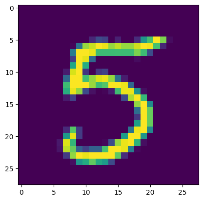

```
Цифра : 5
```

```python
im = plt.imshow(image)
plt.show()
print("Цифра :", label)
```

```python
mnist_test = pd.read_csv("/content/sample_data/mnist_test.csv")
mnist_test.head()
```

|  | 7 | 0 | 0.1 | 0.2 | 0.3 | 0.4 | 0.5 | 0.6 | 0.7 | 0.8 | ... | 0.658 | 0.659 | 0.660 | 0.661 | 0.662 | 0.663 | 0.664 | 0.665 | 0.666 | 0.667 |
| --- | --- | --- | --- | --- | --- | --- | --- | --- | --- | --- | --- | --- | --- | --- | --- | --- | --- | --- | --- | --- | --- |
| 0 | 2 | 0 | 0 | 0 | 0 | 0 | 0 | 0 | 0 | 0 | ... | 0 | 0 | 0 | 0 | 0 | 0 | 0 | 0 | 0 | 0 |
| 1 | 1 | 0 | 0 | 0 | 0 | 0 | 0 | 0 | 0 | 0 | ... | 0 | 0 | 0 | 0 | 0 | 0 | 0 | 0 | 0 | 0 |
| 2 | 0 | 0 | 0 | 0 | 0 | 0 | 0 | 0 | 0 | 0 | ... | 0 | 0 | 0 | 0 | 0 | 0 | 0 | 0 | 0 | 0 |
| 3 | 4 | 0 | 0 | 0 | 0 | 0 | 0 | 0 | 0 | 0 | ... | 0 | 0 | 0 | 0 | 0 | 0 | 0 | 0 | 0 | 0 |
| 4 | 1 | 0 | 0 | 0 | 0 | 0 | 0 | 0 | 0 | 0 | ... | 0 | 0 | 0 | 0 | 0 | 0 | 0 | 0 | 0 | 0 |

5 rows × 785 columns

```python
mnist_train["6"].value_counts()
```

| 6 | count |
| --- | --- |
| 1 | 2243 |
| 7 | 2126 |
| 6 | 2038 |
| 9 | 2023 |
| 3 | 2021 |
| 2 | 1989 |
| 0 | 1962 |
| 4 | 1924 |
| 8 | 1912 |
| 5 | 1761 |

**dtype:** int64

```python
X_train = mnist_train.values[:, 1:]
y_train = mnist_train.values[:, 0]
```

```python
X_test = mnist_test.values[:, 1:]
y_test = mnist_test.values[:, 0]
```

```python
X_train = X_train / 255.0
X_test = X_test / 255.0
```

```python
class NeuralNetwork:
    def __init__(self, input_n, hidden_n, output_n):

        self.W1 = np.random.randn(input_n, hidden_n) * 1e-1
        self.W2 = np.random.randn(hidden_n, output_n) * 1e-1

        self.b1 = np.zeros((1, hidden_n))
        self.b2 = np.zeros((1, output_n))

        self.alpha = 0.1

    @staticmethod
    def relu(x):
        return np.maximum(x, 0)

    @staticmethod
    def softmax(x):
        z = np.exp(x - np.max(x, axis=1, keepdims=True))
        return z / np.sum(z, axis=1, keepdims=True)

    @staticmethod
    def cross_entropy_loss(y_pred, y_true):
        correct_probs = y_pred[np.arange(len(y_true)), y_true]
        loss = -np.mean(np.log(correct_probs))
        return loss

    @staticmethod
    def encode_labels(y):
        mask = np.zeros((y.size, y.max() + 1))
        mask[np.arange(y.size), y] = 1
        return mask

    def forward(self, x):
        self.Z1 = np.matmul(x, self.W1) + self.b1
        self.A1 = self.relu(self.Z1)
        self.Z2 = np.matmul(self.A1, self.W2) + self.b2
        self.A2 = self.softmax(self.Z2)
        return self.A2

    def step(self):
        self.W1 = self.W1 - self.alpha * self.dW1
        self.b1 = self.b1 - self.alpha * self.db1
        self.W2 = self.W2 - self.alpha * self.dW2
        self.b2 = self.b2 - self.alpha * self.db2

    def backward(self, y_pred, X, y):
        m = X.shape[0]

        y_mask = self.encode_labels(y)
        self.dZ2 = y_pred - y_mask

        self.dW2 = (1 / m) * np.matmul(self.A1.T, self.dZ2)
        self.db2 = (1 / m) * np.sum(self.dZ2, axis=0, keepdims=True)

        self.dA1 = np.matmul(self.dZ2, self.W2.T)
        self.dZ1 = self.dA1 * (self.Z1 > 0)

        self.dW1 = (1 / m) * np.matmul(X.T, self.dZ1)
        self.db1 = (1 / m) * np.sum(self.dZ1, axis=0, keepdims=True)
```

```python
model = NeuralNetwork(784, 300, 10)
```

```python
class DataLoader:
    def __init__(self, X, y, batch_size: int = 64):
        self.X = X
        self.y = y
        self.batch_size = batch_size
        self.current_idx = 0

    def __iter__(self):
        self.current_idx = 0
        return self

    def __next__(self):
        if self.current_idx >= self.X.shape[0]:
            raise StopIteration

        X_batch = self.X[self.current_idx:self.current_idx + self.batch_size]
        y_batch = self.y[self.current_idx:self.current_idx + self.batch_size]

        self.current_idx += self.batch_size

        return X_batch, y_batch
```

```python
train_iterator = DataLoader(X_train, y_train, batch_size=64)
test_iterator = DataLoader(X_test, y_test, batch_size=64)
```

```python
import time
```

```python
NUM_EPOCH = 20
for i in range(NUM_EPOCH):

    time1 = time.time()

    print(f"Epoch: {i+1}")
    epoch_accuracy = []
    epoch_loss = []
    for X_batch, y_batch in train_iterator:
        y_pred = model.forward(X_batch)
        loss = model.cross_entropy_loss(y_pred, y_batch)

        model.backward(y_pred, X_batch, y_batch)
        model.step()

        labels_pred = np.argmax(y_pred, axis=1)
        accuracy = np.mean(labels_pred == y_batch)
        epoch_accuracy.append(accuracy)

        epoch_loss.append(loss)

    time2 = time.time()
    print(f"Epoch Accuracy: {sum(epoch_accuracy) / len(epoch_accuracy)}")
    print(f"Epoch Loss: {sum(epoch_loss) / len(epoch_loss)}")
    print(f"Epoch Time: {time2 - time1} s")
```

```
Epoch: 1
Epoch Accuracy: 0.9734891914871688
Epoch Loss: 0.10420411389232821
Epoch Time: 1.9135050773620605 s
Epoch: 2
Epoch Accuracy: 0.9769336803050602
Epoch Loss: 0.09296278854192057
Epoch Time: 1.4455411434173584 s
Epoch: 3
Epoch Accuracy: 0.9795327476038339
Epoch Loss: 0.08318767133833126
Epoch Time: 1.402444839477539 s
Epoch: 4
Epoch Accuracy: 0.9823282747603834
Epoch Loss: 0.0747182857224657
Epoch Time: 1.3910877704620361 s
Epoch: 5
Epoch Accuracy: 0.9848242811501597
Epoch Loss: 0.06734122866758652
Epoch Time: 1.4488859176635742 s
Epoch: 6
Epoch Accuracy: 0.9869209265175719
Epoch Loss: 0.060899875015390494
Epoch Time: 1.4250879287719727 s
Epoch: 7
Epoch Accuracy: 0.9889676517571885
Epoch Loss: 0.05519315582508475
Epoch Time: 1.5158960819244385 s
Epoch: 8
Epoch Accuracy: 0.9901657348242812
Epoch Loss: 0.05017120325301749
Epoch Time: 3.647066116333008 s
Epoch: 9
Epoch Accuracy: 0.9915634984025559
Epoch Loss: 0.04571381029441767
Epoch Time: 1.6474897861480713 s
Epoch: 10
Epoch Accuracy: 0.992611821086262
Epoch Loss: 0.04174268086475187
Epoch Time: 1.44187593460083 s
```

[output cut: 25 more lines]

```
Epoch Accuracy: 0.9976038338658147
Epoch Loss: 0.023357971322100754
Epoch Time: 1.7220196723937988 s
Epoch: 18
Epoch Accuracy: 0.9978534345047924
Epoch Loss: 0.021691853451688288
Epoch Time: 1.3744335174560547 s
Epoch: 19
Epoch Accuracy: 0.9982527955271565
Epoch Loss: 0.020184747101354514
Epoch Time: 1.4360144138336182 s
Epoch: 20
Epoch Accuracy: 0.9983526357827476
Epoch Loss: 0.018821027358078453
Epoch Time: 1.3819193840026855 s
```

```python
test_pred = model.forward(X_test)
loss = model.cross_entropy_loss(test_pred, y_test)
test_pred_labels = np.argmax(test_pred, axis=1)
accuracy = np.mean(test_pred_labels == y_test)
print("Test accuracy: ", accuracy)
print("Test Loss: ", loss)
```

```
Test accuracy:  0.9664966496649665
Test Loss:  0.10977602897989346
```